# MA684 Discussion

Yitong

September 06, 2016

# Introduction

In this discussion, you will learn how to use R Markdown with `knitr` and create a nice report. The base structure for a markdown file contains both R code and Knitr code. Any code between the sets of three backticks is R code and any code outside is Knitr. Chunk options are written in one line. The followings are some popular chunk options.

- `echo=TRUE` - display the command ; `error=FALSE` - do not display any error messages
- `echo=TRUE` - run the code ; `message =FALSE` - do not display any messages
- `include=TRUE` - show the output ; `warning =FALSE` - do not display any warning messages

# Exploratory Data Analysis

You can get the example data from this [link](http://socserv.socsci.mcmaster.ca/jfox/Books/Applied-Regression-3E/datasets/index.html) The code to read in the data is already written for you. Your job is to look at the data and think about the following

1. What are some hypothesis that can be addressed from the data?
2. Does regression seem like a good analysis strategy?
3. Is there some transformation that you can apply so that you can use regression?

## Example: United Nations Social Indicators Data

### Variables:

- region: Africa, America, Asia, Europe, Oceania
- educationMale: Average number of years of education for men
- lifeMale: Expectation of life at birth for men
- lifeFemale: Expectation of life at birth for women
- infantMortality: infant deaths per 1000 live births.

### Making plots

For a quick plot, you can use qplot() which wraps up the details of ggplot. The syntax looks like this `qplot(x, y, data=, color=, shape=, size=, geom=, method=, ...)` The `ggplot2` package provides a more flexible syntax for creating elegant and complex plots. `ggplot(data, mapping) + layer( stat = "", geom = "", position = "", geom_parms = list(),...)`

Now let’s use the example data to do some data visualization.

**Scatterplot**

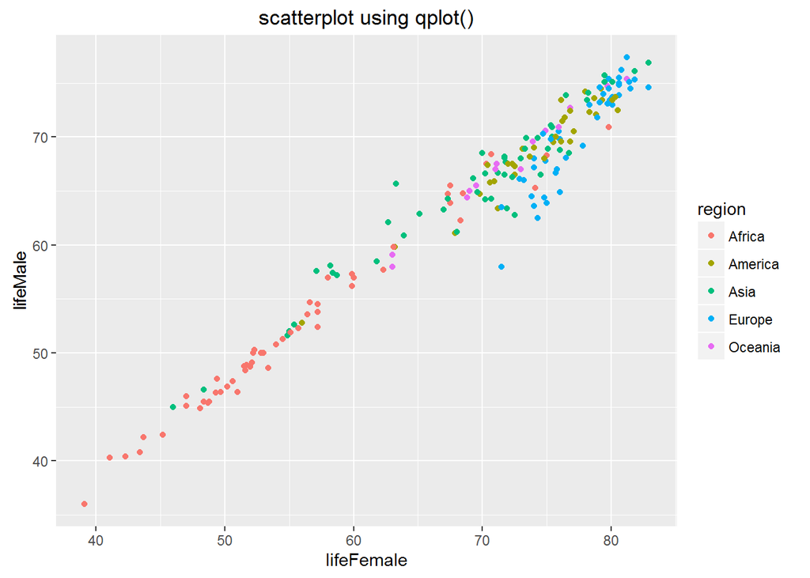

```r
# read data
unitednations<-read.table("http://socserv.socsci.mcmaster.ca/jfox/Books/Applied-Regression-3E/datasets/UnitedNations.txt")

# scatterplot using qplot()
qplot(lifeFemale, lifeMale, data = unitednations, colour = region, main = "scatterplot using qplot()" )
```

Add a smoother to show a trend

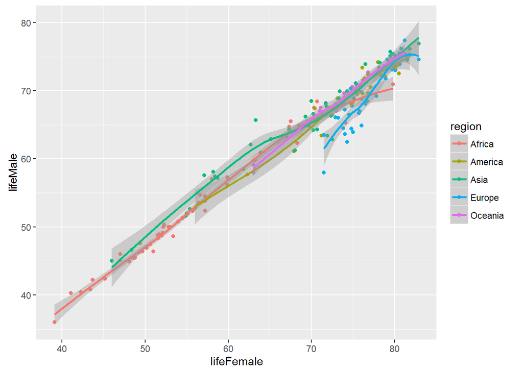

```r
qplot(lifeFemale, lifeMale, data = unitednations, colour = region, geom = c("point", "smooth"))
```

Add a line specified by slope and intercept by using `geom_ablin` in ggplot()

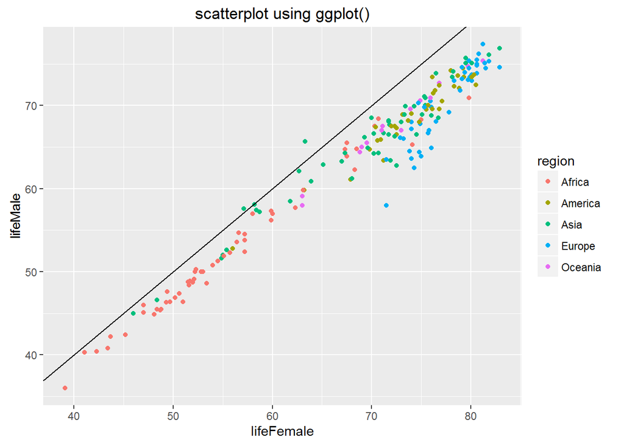

```r
# scatterplot using ggplot()
unitednations_gp <- ggplot(unitednations)

unitednations_gp + aes(x=lifeFemale, y=lifeMale, color=region)+ geom_point()+
                   geom_abline(intercept=0,slope=1) + ggtitle("scatterplot using ggplot()")
```

**Histogram and density plot**

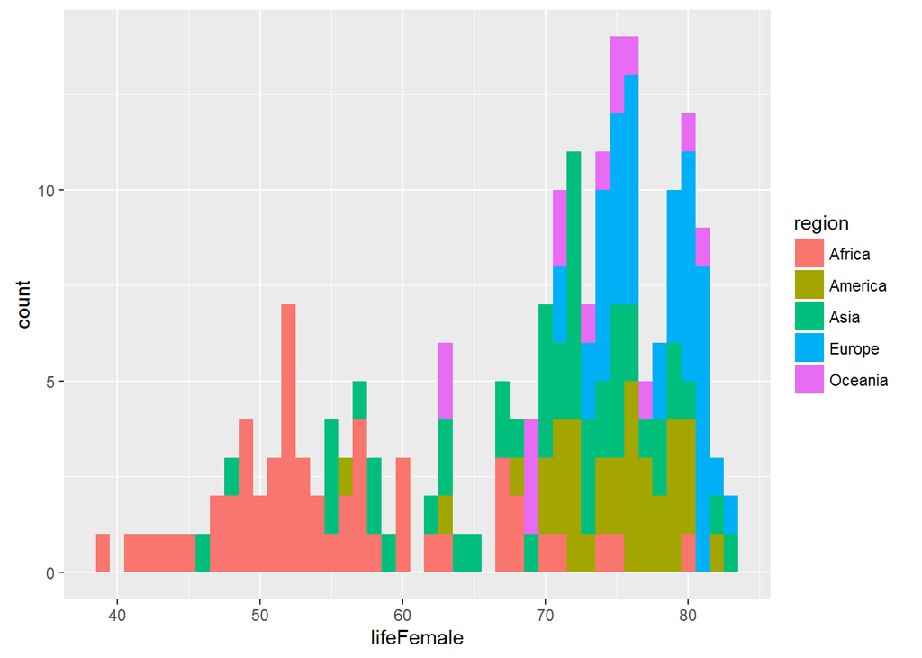

```r
# histogram
unitednations_gp + aes(x=lifeFemale, fill=region)+ geom_histogram(binwidth =1)
```

To compare distributions of “lifeFemale” by regions, we can use a density plot

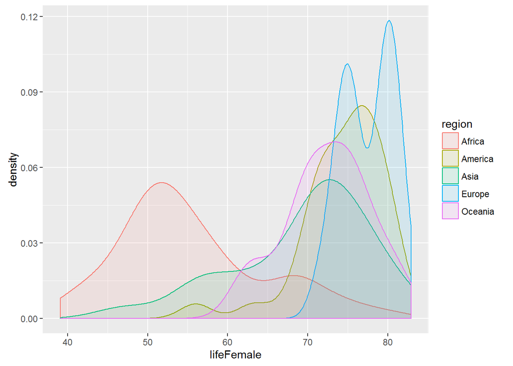

```r
# density plot
unitednations_gp + aes(x=lifeFemale,fill = region, colour = region)+ geom_density(alpha = .1)
```

### Fitting a model

For example, we fit a linear regression model with two predictors (“educationMale”,“region”) and a response variable “lifeMale”.

```r
regout = lm(lifeMale ~ factor(region) + educationMale, data =unitednations)
```

The kable function is sufficient to make a table for the model output, although it doesn’t have many options.

```r
kable(summary(regout)$coef, digits=2 )
```

|  | Estimate | Std. Error | t value | Pr(>\|t\|) |
| --- | --- | --- | --- | --- |
| (Intercept) | 40.13 | 2.39 | 16.81 | 0 |
| factor(region)America | 12.55 | 1.92 | 6.52 | 0 |
| factor(region)Asia | 12.30 | 1.78 | 6.93 | 0 |
| factor(region)Europe | 10.53 | 2.09 | 5.04 | 0 |
| factor(region)Oceania | 10.21 | 3.43 | 2.98 | 0 |
| educationMale | 1.52 | 0.25 | 6.08 | 0 |

## Example: Long’s Data on Occupational Attainment

### Variables:

- experience: possible years of work experience
- education: number of year of formal education
- race: white or nonwhite
- occupation: menial, bluecollar, craft, whitecollar, professional

### Boxplot

Boxplot is good for measuring dispersion and telling outlier points. Note that “occupation” is a categorical variable.

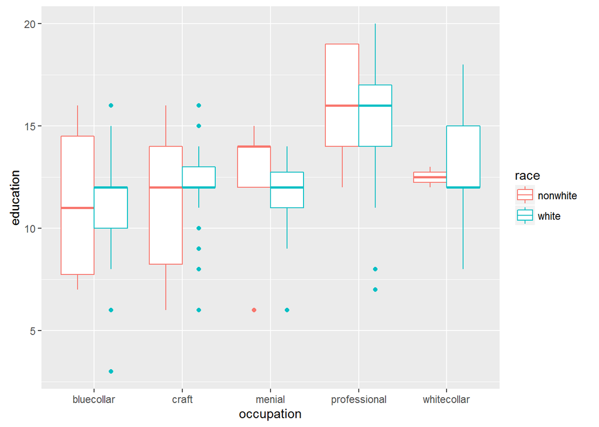

```r
# read data
OA<-read.table("http://socserv.socsci.mcmaster.ca/jfox/Books/Applied-Regression-3E/datasets/GSS-Long.txt")

# boxplot
ggplot(OA) + aes(x=occupation, y=education, color=race)+ geom_boxplot()
```

### Model

In this case, we use a logistic regression to predict the probability of attaining certain occupation, and use kable to show the output.

```r
logout = glm(occupation ~ education+ race + experience, family = binomial(link=logit), data = OA)
kable(summary(logout)$coef, digits=2)
```

|  | Estimate | Std. Error | z value | Pr(>\|z\|) |
| --- | --- | --- | --- | --- |
| (Intercept) | -3.10 | 1.01 | -3.07 | 0.00 |
| education | 0.37 | 0.06 | 5.81 | 0.00 |
| racewhite | -0.71 | 0.62 | -1.14 | 0.25 |
| experience | 0.03 | 0.01 | 2.30 | 0.02 |

## Example: Sahlins’s Data on Agricultural Production in Mazulu Village

### Variables:

- consumers: weighted number of consumers per gardener in each household
- acres: number of acres per gardener tended in each household

Notes: The observations are 20 households in an African village.

### Plot

Draw a scatterplot of acres versus consumers. What kind of relationship can you see? linear or nonlinear?

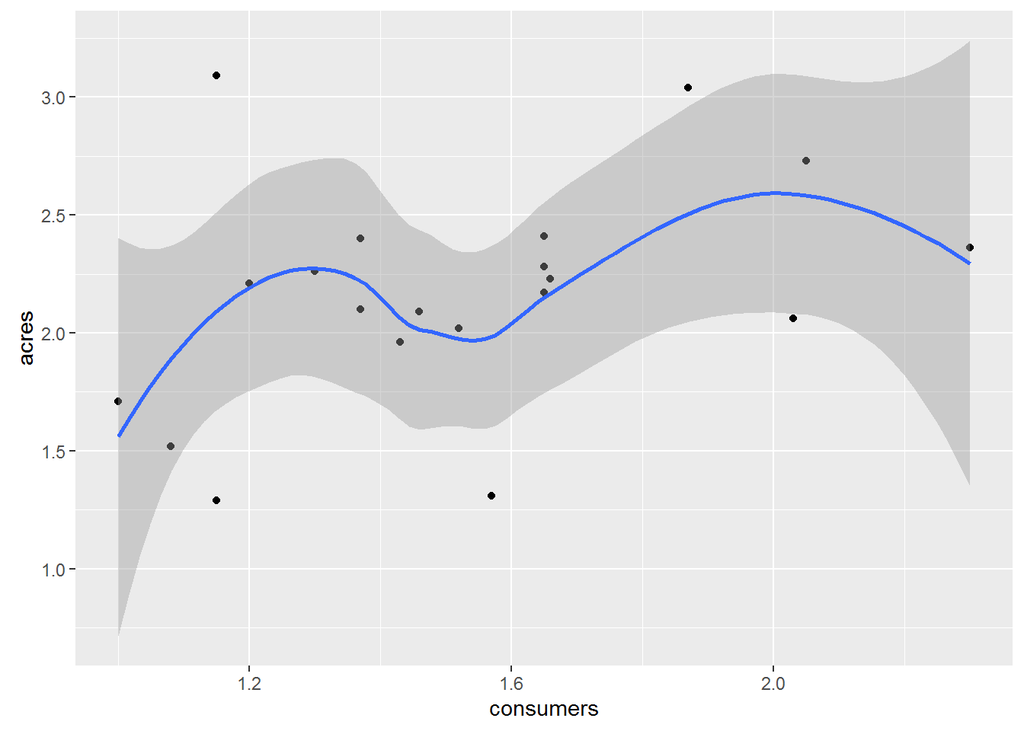

```r
# read data
sahlins<-read.table("http://socserv.socsci.mcmaster.ca/jfox/Books/Applied-Regression-3E/datasets/Sahlins.txt")

# use geom_smooth to help see patterns
ggplot(sahlins) + aes(x=consumers, y=acres)+ geom_point()+ geom_smooth()
```

### Model

The relationship seems to “locally polynomial”, so we use LOESS regression which stands for locally weighted scatterplot smoothing.

```r
regout2 = loess(acres ~ consumers, data =sahlins, span=.5)
summary(regout2)
```

```
## Call:
## loess(formula = acres ~ consumers, data = sahlins, span = 0.5)
##
## Number of Observations: 20
## Equivalent Number of Parameters: 7.23
## Residual Standard Error: 0.4682
## Trace of smoother matrix: 8  (exact)
##
## Control settings:
##   span     :  0.5
##   degree   :  2
##   family   :  gaussian
##   surface  :  interpolate      cell = 0.2
##   normalize:  TRUE
##  parametric:  FALSE
## drop.square:  FALSE
```

Let’s plot fitted values. A nonlinear line looks good in general.

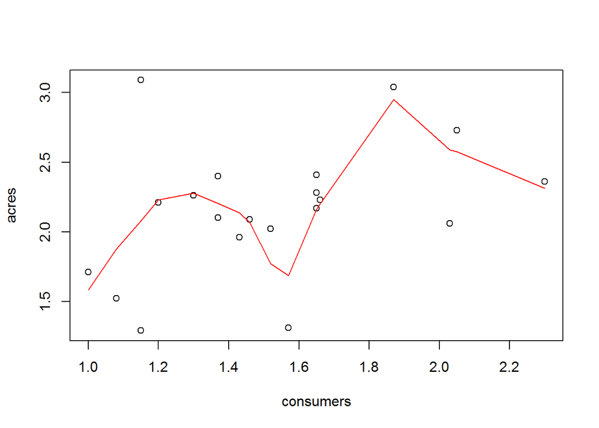

```r
plot(acres ~ consumers,data =sahlins)
i = order(sahlins$consumers)
lines(sahlins$consumers[i],regout2$fitted[i],col="red")
```